# Creación de redes y carga de data

Para trabajar con grafos (redes) hay una serie de programas que podemos utilizar. La gran diferencia radica en el tamaño del archivo que pueden manejar (complejidad de la red), en el costo del programa, la cantidad y actualización de funciones (algoritmos) implementados, y en si requieren o no programación.

## **ESTRUCTURA DE DATOS**

Veamos la imagen de un grafo en wikipedia):

[figure not shown]

De aquí notamos dos componentes básicos:

- los nodos (*vertex*): `6`,`4`,`5`,`1`,`2`,`3`
- los enlaces (*edges*): `6-4`,`4-5`,`4-3`,`5-2`,`5-1`,`2-3`,`2-1`

Los nodos y enlaces podemos representados en una matriz, donde una celda tenga una marca (`1`) que indique si hay enlace entre los nodos. La gráfica debajo muestra esa matriz:

[figure not shown]

Otra manera sería escribir en dos columnas el origen y destino, es decir, los dos nodos que estén conectados por un enlace. La imagen que sigue representa ello:

[figure not shown]

Los enlaces mostrados no tienen direccionalidad (flechas), pero pueden tenerla cuando queramos tener un grafo dirigido. Las redes son grafos, pero "red" es una palabra más familiar que usaremos en nuestras sesiones. Las estructuras de matriz o lista de vertices son compatibles en general, pero el *edgelist*, aun siendo más eficiente, suele no mostrar los nodos de la población bajo estudio que no tenga conexiones con otro nodo (*isolates*).

> ¿Cómo podemos crear esta red en la computadora? Redes pequeñas de este tipo pueden crearse manualmente usando, por ejemplo, Python. Para usar Python, puede instalarlo localmente (en su computadora), se recomienda [ANACONDA](https://www.anaconda.com/download)). Ello no es necesario si desea usar la versión de Python que ofrece GOOGLE, [Colab](https://colab.research.google.com/).

## Creando una red

```python
# _Networkx_ es una librería de Python

import networkx as nx

red1 = nx.Graph()
red1.add_edges_from([(6,4),(4,5),(4,3),(5,2),(5,1),(2,3),(2,1)])
```

```python
red1.nodes()
```

```
NodeView((6, 4, 5, 3, 2, 1))
```

```python
red1.edges()
```

```
EdgeView([(6, 4), (4, 5), (4, 3), (5, 2), (5, 1), (3, 2), (2, 1)])
```

# LECTURA DE ARCHIVOS

La creación manual no es comun en estos día. Generalmente necesitamos preparar datos en archivos que luego sean leidos por otro software o librería especializada. Hay que saber elegir la estructura y la herramienta apropiada para crear una red. Por ejemplo, en [esta hoja de calculo](https://docs.google.com/spreadsheets/u/6/d/e/2PACX-1vReqFHgPvGpZiSozcooJkZOH7kOCvtpgtq0fvuIehQ6MfqM-To93umwRY0pJBZzoCetj_ptmLCpNnGv/pubhtml) podemos ver los datos que utilizó Adolfo Figueroa en su [artículo](https://doi.org/10.1016/j.qref.2006.12.016) "*Competition and circulation of economic elites: Theory and application to the case of Peru*" del 2007, en dos formatos, la matriz de adyacencia (**adjancency matrix**) y la lista de enlaces (**edgelist**). La matriz de adyacencia tiene esta apariencia:

[figure not shown]

Para esta sección, dirigete a este **[enlace](https://drive.google.com/drive/folders/1ycEE-r-LGyCpQl8bcUOCR4lNlVWj14E8?usp=sharing)**, el acceso es con la cuenta *@pucp.edu.pe*.

Simplemente, abre el archivo y crea UNA COPIA en tu propio google drive.

## Usando NETWORKX

Python y Networkx pueden leer la data desde Google Drive. Sigamos estos pasos:

- Paso 1: *Compartir* y *Publicar* tabla en la web:

[figure not shown]

- Paso 2: Obtener el link

[figure not shown]

La primera vez que haga el paso 2, debe presionar la opción "*Publicar*" (aqui ya aparece como *"Publicado"*)

A continuación, si está usando Python, puede guardar el link en Python de manera sencilla:

```python
# link a google sheets entre "comillas"
LinkToGoogle="https://docs.google.com/spreadsheets/d/e/2PACX-1vReqFHgPvGpZiSozcooJkZOH7kOCvtpgtq0fvuIehQ6MfqM-To93umwRY0pJBZzoCetj_ptmLCpNnGv/pub?output=xlsx"
```

Leamos la matriz de adyacencia en Python, para lo cual primero leemos la tabla usando el link en con la libreria *pandas*:

```python
# leyendo matriz de adyacencia

import pandas as pd

adjacency=pd.read_excel(LinkToGoogle, # link a la tabla
                        index_col=0,  # la columna '0' guarda los nombres
                        sheet_name='adjacency') # la tabla tiene este nombre
```

El objeto **adjancency** guarda la tabla. Ahora usamos **from_pandas_adjacency()** de la librería **networkx**, y se crea la red:

```python
# crear red
eliteFromAdjacency=nx.from_pandas_adjacency(adjacency)
```

La red ya está creada, veamos:

```python
# nodos de la red
eliteFromAdjacency.nodes()
```

```
NodeView(('Romero', 'Graña', 'Miro Quesada', 'Moreyra', 'Fort', 'De La Puente', 'Wiese', 'Onrubia', 'Brescia', 'Nicolini', 'Montero', 'Picaso', 'Bentin', 'Benavides', 'Bustamante', 'Woodman Pollit', 'Raffo', 'Piazza', 'Berckemeyer', 'Llosa Barber', 'Beoutis Ledesma', 'Rizo Patron', 'Montori', 'Sotom…
```

```python
# enlaces de la red
eliteFromAdjacency.edges()
```

```
EdgeView([('Romero', 'Graña'), ('Romero', 'Miro Quesada'), ('Romero', 'Moreyra'), ('Romero', 'Fort'), ('Romero', 'De La Puente'), ('Romero', 'Onrubia'), ('Romero', 'Brescia'), ('Romero', 'Nicolini'), ('Romero', 'Bentin'), ('Romero', 'Benavides'), ('Romero', 'Bustamante'), ('Romero', 'Woodman Pollit'…
```

Si quisieramos usar el *edgelist*, necesitamos:

```python
edgeList=pd.read_excel(LinkToGoogle,
                        sheet_name='edgelist') # la tabla tiene este nombre

edgeList
# crear red
eliteFromEdgelist=nx.from_pandas_edgelist(edgeList,edge_attr=True)
```

Veamos la diferencia eentre ambas redes:

- Cantidad de Nodos:

```python
# 'len()' se usa para contar elementos
eliteFromAdjacency.number_of_nodes(), eliteFromEdgelist.number_of_nodes()
```

```
(37, 31)
```

- Cantidad de enlaces:

```python
eliteFromAdjacency.number_of_edges(), eliteFromEdgelist.number_of_edges()
```

```
(135, 135)
```

- Las **islas** del *edgelist*:

```python
list(nx.isolates(eliteFromEdgelist))
```

```
[]
```

- Las islas del *adjacency*:

```python
list(nx.isolates(eliteFromAdjacency))
```

```
['Lucioni',
 'Rodriguez Rodríguez',
 'Custer',
 'Ikeda',
 'Cogorno',
 'Arias Davila']
```

La red **eliteFromEdgelist** puede completarse:

```python
eliteFromEdgelist.add_nodes_from(['Lucioni', 'Rodriguez Rodríguez', 'Custer', 'Ikeda', 'Cogorno', 'Arias Davila'])
```

Ahora tiene los mismos nodos:

```python
eliteFromEdgelist.number_of_nodes()
```

```
37
```

Y claro, sus islas:

```python
list(nx.isolates(eliteFromEdgelist))
```

```
['Lucioni',
 'Rodriguez Rodríguez',
 'Custer',
 'Ikeda',
 'Cogorno',
 'Arias Davila']
```

### Exportación

Las redes creadas con Networkx pueden exportarse en diferentes formatos, que serán útiles en otros programas. Aquí grabaremos en el formato GML y GRAPHML:

```python
filename1='eliteFromAdjacency.gml' # nombre incluye 'donde'
filename2='eliteFromAdjacency.graphml'

# guardando:
nx.write_gml(eliteFromAdjacency,filename1)

nx.write_graphml(eliteFromAdjacency,filename2)
```

# VISUALIZACION DE REDES

Es muy común producir gráficos de redes. La gráficas, si son bien hechas, pueden resaltar algunas propiedades de la red. No siempre es posible lograrlo cuando la red es muy grande y no muestra una estructura clara.

## Usando NETWORKX

Tenemos activa la red *eliteFromAdjacency*. Visualizarla con Networkx es muy sencillo:

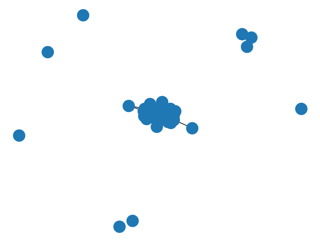

```python
nx.draw(eliteFromAdjacency)
```

La ubicacion de los nodos sigue por lo general algun algoritmo, este es otro:

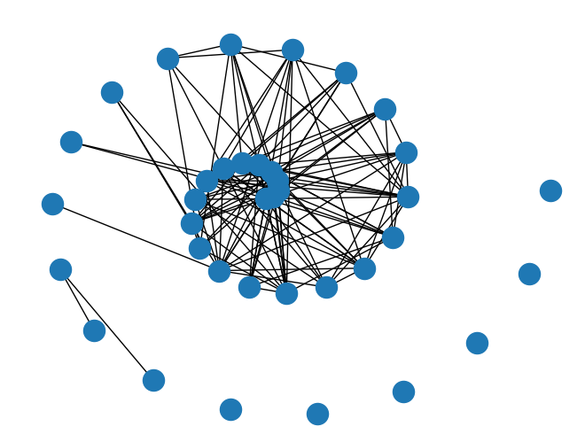

```python
pos = nx.spiral_layout(eliteFromAdjacency) #algoritmo spiral
nx.draw(eliteFromAdjacency, pos=pos)
```

Hay muchos *layouts* disponibles, los de Networkx puedes revisarlos [aquí](https://networkx.org/documentation/stable/reference/drawing.html#).

## Usando GEPHI

Gephi es un software de visualización y exploración de redes, de código abierto y gratuito. El Gephi debe instalarse en la computadora directamente desde su [página web](https://gephi.org/users/download/).

Hasta aquí tenemos varios archivos:

- Un excel con la matriz de adyacencia y el edgelist.
- Un GML con la red ya creada en Python.
- Un GRAPHML con la red ya creada en Python.

> Estos archivos no se pueden leer desde Google, GEPHI sólo lo lee desde tu computadora. Puedes crear una carpeta para esta sesión, y descarga o mueve los archivos ahí.

Veamos como abrir la matriz de adyacencia en Gephi:

1. Abre GEPHI, y ve a la opcion **FILE** del menu superior, selecciona la opción indicada:

[figure not shown]

2. Busca el archivo con la matriz de adyacencia y abrelo:

[figure not shown]

3. Selecciona lo que corresponde, recuerda que que Excel puede haber varias hojas.

[figure not shown]

4. En el paso siguiente, solo selecciona esta opción:

[figure not shown]

5. En esta ventana, asegurate que **GRAPH TYPE** sea el correcto. Aqui debe ser UNDIRECTED. Asi mismo, crea un nuevo espacio de trabajo.

[figure not shown]

6. Verifica que a esta altura, tienes algo muy similar a esto:

[figure not shown]

> Los archivos creados por Python se abren directamente. Usemos el `GRAPHML`:

paso 1:

[figure not shown]

paso 2:

[figure not shown]

paso 3:

[figure not shown]

Listo!

[figure not shown]

## Ejercicio 1

[figure not shown]

Y logre que se vea mejor los nombres de los nodos, algo así:

[figure not shown]

## En Python es algo sencillo

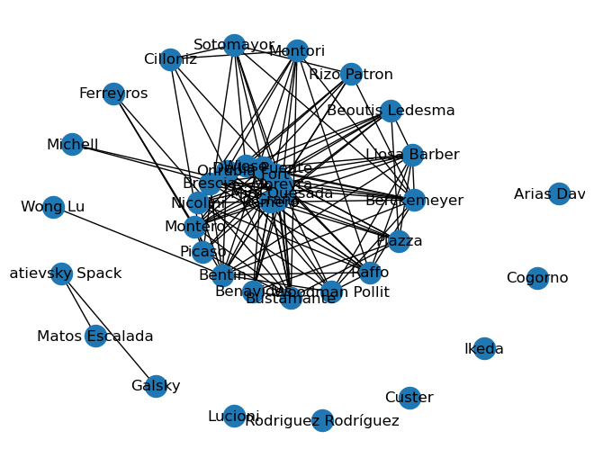

```python
pos = nx.spiral_layout(eliteFromAdjacency) # algoritmo spiral
nx.draw(eliteFromAdjacency, pos=pos, with_labels=True)
```

Pero, saber los comandos a veces toma tiempo:

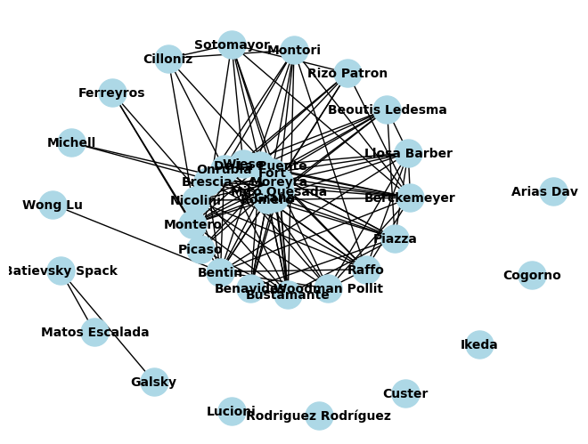

```python
nx.draw(
    eliteFromAdjacency,
    pos=pos,
    with_labels=True,
    node_color='lightblue',   # Cambia el color del nodo para que resalte el texto
    font_size=10,             # Ajusta el tamaño de la letra
    font_weight='bold',       # Hace la letra más legible
    node_size=500             # Agranda el nodo si el texto es muy largo
)
```

## Ejercicio 2

¿Cómo te aproximarías al gráfico anterior?

## Ejercicio 3

Para esta parte crearemos una red a partir de una historia ([VER AQUI](https://drive.google.com/file/d/1skvkhOhJHYyiW0LlteIbknkxcdJ5gh8d/view?usp=sharing)).

En la historia, identifica:

- nodos (cientifico)
- enlaces (entre cientifico, quien conoció a quien)

En un Excel crea una matriz de adyacencia o un edgelist usando lo anterior. Luego lo lees en Python, y creas la red. Esa red la exportala a GEPHI como archivo GML o GRAPHML. Una vez en Gephi, muestra la red con el nombre de sus nodos.

## Redes con 'edges' dirigidos

Cuando creamos una red no-dirigida con:

```
> ....add_edges_from([(6,4),(4,5),(4,3),(5,2),(5,1),(2,3),(2,1)])
```

El edge (6,4) significa que (4,6) existe. La relación es recíproca o simétrica.

Un grafo dirigido indica que la relación no es *necesariamente* recíproca. Si no lo es, debemos crear un grafo o red dirigida:

```python
red2 = nx.DiGraph()

red2.add_edges_from([(6,4),(4,5),(4,3),(5,2),(5,1),(2,3),(2,1)])

# cuales tenemos:
red2.edges()
```

```
OutEdgeView([(6, 4), (4, 5), (4, 3), (5, 2), (5, 1), (2, 3), (2, 1)])
```

En las redes dirigidas como la creada, `(6,4)` es diferente a `(4,6)`, entonces, si ambos edges existen, deben incluirse manera explícita.

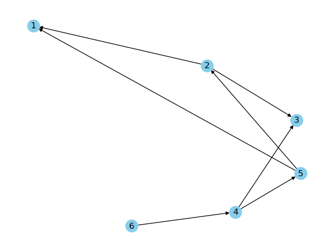

```python
# La forma rápida y directa
pos = nx.spiral_layout(red2) # algoritmo spiral
nx.draw(red2, with_labels=True, node_color="skyblue", pos=pos)
```

### Ejemplo ficticio: Relaciones de asesoría en un departamento de Historia

Todos los nodos son profesores del departamento. Los más antiguos fueron asesorados por figuras fundadoras, los de mediana edad por los antiguos, y los jóvenes por los de mediana edad. La red captura el linaje intelectual: quién formó a quién.

| Generación | Profesores | Años de doctorado |
| --- | --- | --- |
| **Fundadores** (1ª) | Elena Vargas, Roberto Díaz | 1980–1985 |
| **Consolidados** (2ª) | Carlos Méndez, Ana Ruiz, Bruno Soto, Laura Vega | 1995–2005 |
| **Jóvenes** (3ª) | Martín Herrera, Lucía Fernández, Sofía Reyes, Diego Ortega | 2015–2022 |

Quien asesoró a quien:

| Asesorado (más joven) | Asesor (más antiguo) | Año | Tema de tesis |
| --- | --- | --- | --- |
| Carlos Méndez | Elena Vargas | 1995 | Historia política comparada |
| Ana Ruiz | Elena Vargas | 1998 | Historia social del trabajo |
| Bruno Soto | Roberto Díaz | 2000 | Historia urbana latinoamericana |
| Laura Vega | Roberto Díaz | 2003 | Historia de la educación |
| Martín Herrera | Carlos Méndez | 2016 | Historia de los movimientos obreros |
| Lucía Fernández | Carlos Méndez | 2018 | Historia del sindicalismo |
| Sofía Reyes | Ana Ruiz | 2019 | Historia de género y familia |
| Diego Ortega | Bruno Soto | 2021 | Historia de las migraciones internas |
| Diego Ortega | Laura Vega | 2021 | Metodología cualitativa (coasesoría) |

```python
asesorias = nx.DiGraph()

# Todos son profesores del departamento
profesores = [
    "Elena Vargas", "Roberto Díaz",           # 1ª generación
    "Carlos Méndez", "Ana Ruiz", "Bruno Soto", "Laura Vega",  # 2ª generación
    "Martín Herrera", "Lucía Fernández", "Sofía Reyes", "Diego Ortega"  # 3ª
]
asesorias.add_nodes_from(profesores)

# Flecha: asesor → asesorado (dirección del legado intelectual)
asesorias.add_edges_from([
    # 1ª → 2ª generación
    ("Elena Vargas", "Carlos Méndez"),
    ("Elena Vargas", "Ana Ruiz"),
    ("Roberto Díaz", "Bruno Soto"),
    ("Roberto Díaz", "Laura Vega"),
    # 2ª → 3ª generación
    ("Carlos Méndez", "Martín Herrera"),
    ("Carlos Méndez", "Lucía Fernández"),
    ("Ana Ruiz", "Sofía Reyes"),
    ("Bruno Soto", "Diego Ortega"),
    ("Laura Vega", "Diego Ortega"),  # coasesoría
])

#veamos
print(asesorias)
```

```
DiGraph with 10 nodes and 9 edges
```

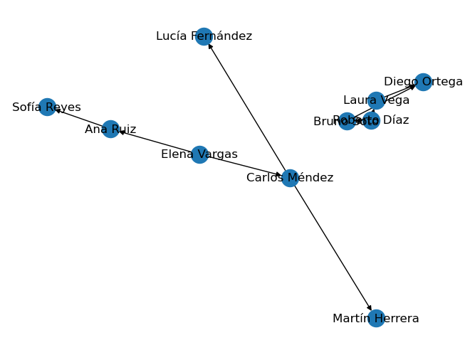

```python
nx.draw(asesorias,with_labels=True)
```

## Redes bipartitas

Un grafo bipartito es una red donde los nodos se dividen en dos grupos distintos (dos "equipos", dos "categorías"), y las conexiones solo existen entre grupos, nunca dentro del mismo grupo.

No hay líneas que unan nodos del mismo grupo.

### Ejemplo ficticio: Prestación de servicios profesionales

En este ejemplo, los nodos son personas reales que ofrecen servicios especializados, y organizaciones (empresas cliente) que contratan esos servicios.

- Conjunto U (10 nodos): profesionales independientes.
- Conjunto W (3 nodos): empresas cliente que reciben el servicio.

La relación es dirigida: persona → empresa significa "esta persona presta un servicio a esta empresa". La flecha indica la dirección del servicio, no del dinero.

**Los profesionales**

| Persona | Especialidad | Nota |
| --- | --- | --- |
| Ana | Auditoría financiera | Ex Big Four, ahora freelance |
| Bruno | Auditoría financiera | Socio de Ana en algunos proyectos |
| Carlos | Auditoría financiera | También hace consultoría de riesgos |
| Diana | Seguridad informática | Especialista en pentesting |
| Elena | Seguridad informática | Certificada en normativas ISO |
| Federico | Seguridad informática | Experto en respuesta a incidentes |
| Gabriela | Seguridad informática | La más senior del grupo, también asesora en compliance |
| Hugo | Desarrollo de software | Full-stack, recién independiente |
| Isabel | Desarrollo de software | Especialista en arquitectura cloud |
| Javier | Desarrollo de software | Enfocado en inteligencia artificial aplicada |

**empresas que reciben servicio**

| Empresa | Sector | Servicio contratado |
| --- | --- | --- |
| FinanzasCorp | Financiero | Auditoría externa, revisión de estados |
| TechSecure | Tecnología | Auditoría de seguridad, pentesting |
| InnovaDigital | Tecnología | Desarrollo a medida, consultoría técnica |

**Edge list: quién presta servicio a quién**

| Persona | Empresa cliente | Servicio prestado |
| --- | --- | --- |
| Ana | FinanzasCorp | Auditoría anual de estados financieros |
| Bruno | FinanzasCorp | Revisión de procesos contables |
| Carlos | FinanzasCorp | Auditoría de riesgos operativos |
| Carlos | TechSecure | Consultoría de riesgos en ciberseguridad |
| Diana | TechSecure | Pentesting de infraestructura |
| Elena | TechSecure | Auditoría de cumplimiento normativo ISO 27001 |
| Federico | TechSecure | Respuesta a incidente de seguridad |
| Gabriela | TechSecure | Auditoría de seguridad integral |
| Gabriela | InnovaDigital | Asesoría en compliance de datos |
| Hugo | InnovaDigital | Desarrollo de plataforma web |
| Isabel | InnovaDigital | Migración de arquitectura a cloud |
| Javier | InnovaDigital | Desarrollo de módulo de IA |

```python
from networkx.algorithms import bipartite

# 1. CREAMOS EL GRAFO DIRIGIDO BIPARTITO
red_servicios = nx.DiGraph()

# Conjunto U: profesionales (bipartite=0)
profesionales = [
    "Ana", "Bruno", "Carlos", "Diana", "Elena",
    "Federico", "Gabriela", "Hugo", "Isabel", "Javier"
]

# Conjunto W: empresas cliente (bipartite=1)
empresas = ["FinanzasCorp", "TechSecure", "InnovaDigital"]

red_servicios.add_nodes_from(profesionales, bipartite=0)
red_servicios.add_nodes_from(empresas, bipartite=1)

# EDGES DIRIGIDOS: profesional → empresa (presta servicio)
red_servicios.add_edges_from([
    # Auditores financieros → FinanzasCorp
    ("Ana", "FinanzasCorp"),
    ("Bruno", "FinanzasCorp"),
    ("Carlos", "FinanzasCorp"),
    # Carlos también asesora a TechSecure en riesgos
    ("Carlos", "TechSecure"),
    # Especialistas en seguridad → TechSecure
    ("Diana", "TechSecure"),
    ("Elena", "TechSecure"),
    ("Federico", "TechSecure"),
    ("Gabriela", "TechSecure"),
    # Gabriela también asesora a InnovaDigital en compliance
    ("Gabriela", "InnovaDigital"),
    # Desarrolladores → InnovaDigital
    ("Hugo", "InnovaDigital"),
    ("Isabel", "InnovaDigital"),
    ("Javier", "InnovaDigital"),
])

# que tenemos?
print(red_servicios,"¿Es bipartita la red?", bipartite.is_bipartite(red_servicios))
```

```
DiGraph with 13 nodes and 12 edges ¿Es bipartita la red? True
```

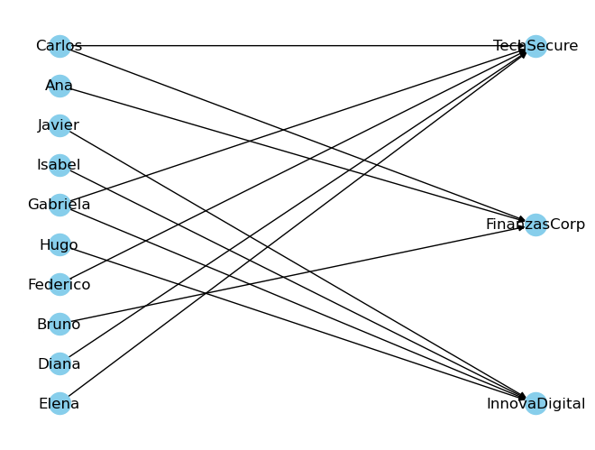

```python
# 2. Configurar la disposición en dos columnas (bipartite_layout)
pos = nx.bipartite_layout(red_servicios, profesionales)

nx.draw(
    red_servicios,
    pos,
    with_labels=True,
    node_color="skyblue")
```

> Una red bipartita conecta dos mundos distintos; pero a veces lo que nos interesa no es la relación cruzada, sino la relación dentro de uno de los dos mundos. La proyección es el proceso de colapsar la red bipartita en una red unipartita: conservamos solo los nodos de uno de los dos conjuntos, y conectamos dos nodos entre sí, si compartían al menos un vecino en el mundo opuesto.

Aqui vemos la proyeccción de la `red_servicios` sobre los nodos de profesionales, ya es una red unipartita no dirigida, donde el edge representa `han dado servicios a la misma empresa`

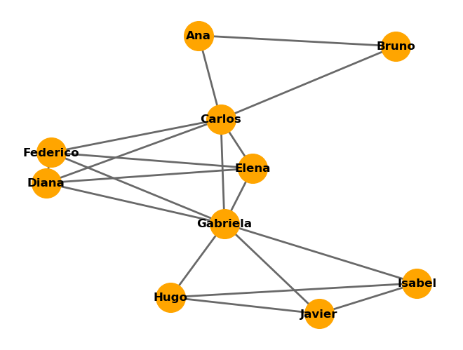

```python
red_unipartita = bipartite.projected_graph(red_servicios.to_undirected(), profesionales)

# 3. Graficar solo la red unipartita

pos = nx.spring_layout(red_unipartita, seed=42)

nx.draw(
    red_unipartita,
    pos,
    with_labels=True,
    node_color="orange",
    node_size=900,
    font_weight="bold",
    font_size=12,
    edge_color="dimgray",
    width=2,
)
```

## Ejercicio 4

### Parte 1

Para esta parte crearemos una red a partir de esta historia ([VER AQUI](https://drive.google.com/file/d/11H1SdDwT4tKdqCFKeEwXwslVD3bcsdbk/view?usp=sharing)).

En la historia, identifica nodos y enlaces. En un Excel crea una matriz de adyacencia o un edgelist usando lo anterior. Luego lo lees en Python, y creas la red, , si es una bipartita, proyectala a unipartita. Esa red la exportala a GEPHI como archivo GML o GRAPHML. Una vez en Gephi, muestra la red con el nombre de sus nodos.

### Parte 2

Para esta parte crearemos una red a partir de esta historia ([VER AQUI](https://drive.google.com/file/d/1rCjhJu99BPm12jjST8ZNxqFCfxJ3cBOQ/view?usp=sharing)).

En la historia, identifica nodos y enlaces. En un Excel crea una matriz de adyacencia o un edgelist usando lo anterior. Luego lo lees en Python, y creas la red, , si es una bipartita, proyectala a unipartita. Esa red la exportala a GEPHI como archivo GML o GRAPHML. Una vez en Gephi, muestra la red con el nombre de sus nodos.